# First Stage Report

## The work we have done

Before the summer, we have done the following:

- We have 62 barrels with manually identified grooves (this can be extended, e.g. FAU 330 is not one of those)
- We have gone through the matching process for the (all) 2232 known matches, sampled 3276 known non-matches from the above data set (these numbers can be changed)
- Fitted the beta-mixture distribution with 2 or 3 components for the KNM and KM, with all the data, with the code, e.g.:

```r
fau330_knm_beta_no_A <- betamix(ccf~1|1, data = fau330_knm_no_A, k = 2)
```

- Different samples with the fit: ten-fold samples, cummulated samples, some single barrel cases
- Some summarized statistics for those comparison are shown in the tables (also see this-is-us repo), some plots are also drawn

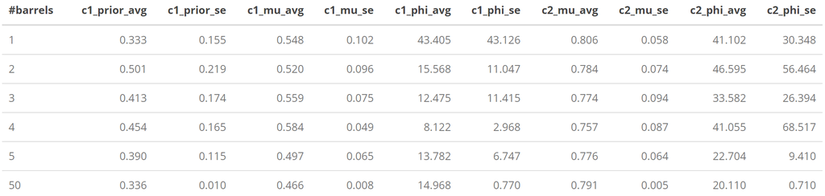

KM

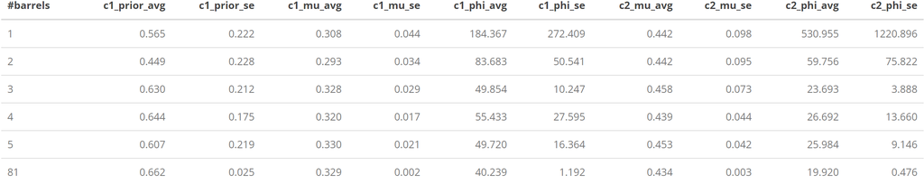

KNM

## What we focus now

- How does this model fit work for the single barrel case? (with one bullet left out as the suspect bullet from the crime scene, some more detailed metric to this question need to be clear)
- How is the fit for the single barrel case compared with the full data fit we have? (how to compare, to what extent, with other sample size?)

## The new progress

To address the above two questions, I refit the models(KM and KNM) to FAU 330 with bullet A left out. And then fit the models including bullet A as we would do in reality, get all possible comparisons including bullet A, i.e. compare bullet A to the test fired bullets. By doing this, we got four models, with two for known bullets, with two for the bullet A compared to the known bullets.

First we should have a look at the original models we estimated before we go to the inference. Note that, the components are always reordered to make the component with smaller mean value be the first component. So the p1 is the prior probability for the first component, is also the prior probability for the component on the left hand side. Also notice that the p1 of fau330_km_beta_no is much larger than the p1 of full_km_model, however, this doesn’t mean the function reversed the two components. The reason is the estimation for the fau330_km_beta_no is done with only 18 obeservations which is not good to estimate two components, the two components both have large enough mean(both similar to the second component of the full_km_model).

```r
estimated_model <- extract_params(cv_summary(list(fau330_km_beta_no_A, fau330_knm_beta_no_A, fau330_km_beta_A,fau330_knm_beta_A, full_km_model, full_knm_model)))

rownames(estimated_model) <- c("fau330_km_beta_no_A", "fau330_knm_beta_no_A", "fau330_km_beta_A", "fau330_knm_beta_A", "full_km_model", "full_knm_model")

estimated_model %>% round(digits = 2) %>%kable() %>% kable_styling(bootstrap_options = c("striped", "hover"))
```

|  | p1 | c1_alpha | c1_beta | c1_mu | c1_phi | c2_alpha | c2_beta | c2_mu | c2_phi |
| --- | --- | --- | --- | --- | --- | --- | --- | --- | --- |
| fau330_km_beta_no_A | 0.63 | 31.26 | 13.25 | 0.70 | 44.50 | 63.33 | 9.74 | 0.87 | 73.07 |
| fau330_knm_beta_no_A | 0.31 | 39.45 | 114.29 | 0.26 | 153.73 | 14.06 | 21.88 | 0.39 | 35.94 |
| fau330_km_beta_A | 0.47 | 17.05 | 5.70 | 0.75 | 22.75 | 17.42 | 5.69 | 0.75 | 23.10 |
| fau330_knm_beta_A | 0.16 | 48.81 | 156.33 | 0.24 | 205.14 | 13.58 | 23.55 | 0.37 | 37.14 |
| full_km_model | 0.35 | 6.79 | 7.76 | 0.47 | 14.55 | 15.94 | 4.21 | 0.79 | 20.15 |
| full_knm_model | 0.66 | 13.37 | 27.27 | 0.33 | 40.63 | 8.68 | 11.35 | 0.43 | 20.03 |

Then I did bootstrap inferences as follows:

1. For a given model (e.g. the km distritbution of FAU 330 without bullet A), I use the estimated distribution to generate a number of new samples with equal sample size to the original data(e.g. for km of FAU 330 without A, this is just 18). Here I totally generated 3000 bootstrap samples.
2. Then construct a basic parametric bootstrap intervals for our original estimation based on the bootstrap samples.

The results (90% bootstrap confidence intervals) for the four models of FAU 330 and two models of the full data are shown in the below. (These are not edited to show in a nicer format since the list can label each of the sets of intervals better with a dollar sign, don’t how to achieve this in a data.frame)

```r
bootstrap90_CI <- readRDS(file.path(datapath,"bootstrap90_CI.rds"))
bootstrap90_CI
```

```
## $No_A_km
##                 p1  c1_alpha    c1_beta     c1_mu     c1_phi   c2_alpha
## 90%lower 0.5453819  1.624465  0.2719836 0.7869415   1.614337   9.712947
## 90%upper 2.0017687 92.256906 27.3028276 1.0601394 117.594662 337.831996
##             c2_beta     c2_mu     c2_phi
## 90%lower  0.6542143 0.9842335   9.614022
## 90%upper 15.0592746 1.1806368 290.347207
##
## $NO_A_knm
##                 p1  c1_alpha    c1_beta     c1_mu    c1_phi  c2_alpha  c2_beta
## 90%lower 0.1726562  27.25958   77.58226 0.1523792  105.4345  9.809633 24.51217
## 90%upper 0.3937920 336.42377 2051.24412 0.2653453 2139.3327 42.224793 75.88920
##              c2_mu    c2_phi
## 90%lower 0.2966161  32.71788
## 90%upper 0.3729575 117.20814
##
## $A_km
##                 p1  c1_alpha   c1_beta     c1_mu    c1_phi   c2_alpha
## 90%lower 0.2691468  1.477005 0.1447473 0.8960723  1.229977  0.8122002
## 90%upper 0.9280722 51.473138 9.3506113 1.3130528 56.005601 55.8684127
##             c2_beta     c2_mu    c2_phi
## 90%lower  0.3302614 0.6741293  1.091327
## 90%upper 11.8301852 0.9109142 63.140913
##
## $A_knm
##                  p1  c1_alpha  c1_beta     c1_mu     c1_phi  c2_alpha  c2_beta
## 90%lower 0.03721264  18.01265   56.591 0.1289341   74.58053  3.547577 11.48598
## 90%upper 0.22607559 558.48414 4170.935 0.2519457 4124.24567 17.375320 51.77403
##             c2_mu   c2_phi
## 90%lower 0.250065 13.75216
## 90%upper 0.277403 64.39404
```

```r
bootstrap_full_90_CI <- readRDS(file.path(datapath,"bootstrap_full_90_CI.rds"))
bootstrap_full_90_CI
```

```
## $full_km
##                 p1 c1_alpha  c1_beta     c1_mu   c1_phi c2_alpha   c2_beta
## 90%lower 0.2357406 5.497527 6.360039 0.4514835 11.89460 12.24580 0.8621828
## 90%upper 0.4245763 7.592709 8.584361 0.4790470 16.13715 16.94112 1.1857746
##             c2_mu    c2_phi
## 90%lower 1.223811  9.837862
## 90%upper 1.267752 13.523734
##
## $full_knm
##                 p1 c1_alpha  c1_beta     c1_mu   c1_phi  c2_alpha  c2_beta
## 90%lower 0.6349639 11.21603 22.23037 0.3260163 33.44386  7.868474 13.80659
## 90%upper 0.8193603 13.88017 28.44288 0.3372927 42.28701 11.959820 17.65332
##              c2_mu   c2_phi
## 90%lower 0.3680528 21.23796
## 90%upper 0.4103167 29.43583
```

Besides the individual confidence intervals, we also test if some models are the same, e.g. if the km distribution for the three known bullets in FAU 330 without bullet A the same as the km distribution for the comparisons between bullet A and other known bullets. So we construct the bootstrap intervals as following:

1. Since we have 3000 bootstrap samples for every model, if we assume iid(which actually is), we can simply match the pair of sampled models for different original estimated models, and calculate the difference, as a bootstrap sample for the difference(whatever way used to match the pairs as long as not to reuse any of them should get same theorical properties). The difference between the original estimated models is the point estimation for the difference.
2. Construct bootstrap confidence intervals for the diffence as shown below

```r
bootstrap90_CI_diff <- readRDS(file.path(datapath,"bootstrap90_CI_diff.rds"))
bootstrap90_CI_diff
```

```
## $km_noA_minus_A
##              p1_diff c1_alpha_diff c1_beta_diff c1_mu_diff c1_phi_diff
## 90%lower -0.09703423     -54.13091    -193.6351 -0.1591928   -246.9479
## 90%upper  0.58789563      98.36080     308.8490  0.1933979    404.9581
##          c2_alpha_diff c2_beta_diff c2_mu_diff c2_phi_diff
## 90%lower     -5.219547    -8.907164 0.03208678   -14.01722
## 90%upper     44.401799    37.001933 0.15866667    80.42599
##
## $knm_noA_minus_A
##              p1_diff c1_alpha_diff c1_beta_diff  c1_mu_diff c1_phi_diff
## 90%lower 0.009591595     -524.8114    -576.2577 -0.23414399  -1099.9418
## 90%upper 0.798171278      149.0494     156.9552  0.03124473    305.1786
##          c2_alpha_diff c2_beta_diff c2_mu_diff c2_phi_diff
## 90%lower     -260.8735   -122.21329  0.1285148   -389.1996
## 90%upper      424.9823     78.74909  0.3805724    524.1036
```

The following are the comparisons between the distributions for the three known bullets and the full data ones

```r
bootstrap_full_90_CI_diff <- readRDS(file.path(datapath,"bootstrap_full_90_CI_diff.rds"))
bootstrap_full_90_CI_diff
```

```
## $km_330_minus_full
##            p1_diff c1_alpha_diff c1_beta_diff c1_mu_diff c1_phi_diff
## 90%lower 0.2546809    -544.71582   -625.96525  0.3132878 -1148.67769
## 90%upper 0.8321895      45.84204     12.84124  0.4785832    58.91721
##          c2_alpha_diff c2_beta_diff  c2_mu_diff c2_phi_diff
## 90%lower     -300.2788   -116.24115 -0.10929850   -412.2109
## 90%upper      100.9197     22.65472  0.01717278    123.2200
##
## $knm_330_minus_full
##             p1_diff c1_alpha_diff c1_beta_diff  c1_mu_diff c1_phi_diff
## 90%lower -0.6857601       9.00541     35.55018 -0.25150278    44.92733
## 90%upper -0.3167091      62.75147    199.71982 -0.06569795   262.50323
##          c2_alpha_diff c2_beta_diff   c2_mu_diff c2_phi_diff
## 90%lower     -1.914955     9.719195 -0.128730214    7.803136
## 90%upper     14.771592    23.385235 -0.001034447   37.983265
```

The following are the comparisons between the distributions for FAU 330 bullet A(compared to other known bullets) and the full data ones

```r
bootstrap_full_90_CI_diff_withA <- readRDS(file.path(datapath,"bootstrap_full_90_CI_diff_withA.rds"))
bootstrap_full_90_CI_diff_withA
```

```
## $km_330withA_minus_full
##             p1_diff c1_alpha_diff c1_beta_diff c1_mu_diff c1_phi_diff
## 90%lower -0.1712299    -168.34337 -220.6474096  0.4076826  -389.81686
## 90%upper  0.4711324      22.08356    0.4620647  0.6071077    22.28276
##          c2_alpha_diff c2_beta_diff c2_mu_diff c2_phi_diff
## 90%lower    -353.32294    -77.82627 -0.4168102  -446.66685
## 90%upper      15.34273     18.57472 -0.1944833    33.35076
##
## $knm_330WithA_minus_full
##             p1_diff c1_alpha_diff c1_beta_diff  c1_mu_diff c1_phi_diff
## 90%lower -1.0796728     -46.73193    -143.9396 -0.29533005   -190.0624
## 90%upper -0.4760139      81.16933     282.8112 -0.07917995    363.9301
##          c2_alpha_diff c2_beta_diff c2_mu_diff c2_phi_diff
## 90%lower    -34.579386    -15.67345 -0.1968013   -49.95648
## 90%upper      7.298625     22.11062 -0.1196303    29.30254
```